# Supervised Learning III

Tuning a Pipeline

# Goal

Our goal for this exercise sheet is to learn how we can tune a nonlinear pipeline consisting of multiple `PipeOp`s generated with `mlr3pipelines`. The underlying mechanism is that we transform our pipeline into a proper learner. As such we can tune the hyperparameters of the learner jointly with the hyperparameters of each preprocessing step.

# German Credit Dataset (dirty)

We use a dirty version of the German credit dataset of Prof. Dr. Hans Hoffman of the University of Hamburg in 1994, which contains 1000 datapoints reflecting bank customers. The dataset is available at the UCI repository as [Statlog (German Credit Data) Data Set](https://archive.ics.uci.edu/ml/datasets/Statlog+%28German+Credit+Data%29). We artificially introduced missing values to the numeric features.

```r
library("mlr3verse")
library("data.table")
task = tsk("german_credit")
dt = task$data()

set.seed(2023)
dt = dt[sample(task$row_ids, size = 100), duration := NA]
dt = dt[sample(task$row_ids, size = 100), amount := NA]
dt = dt[sample(task$row_ids, size = 100), age := NA]
task = as_task_classif(dt, id = "german_credit_NA", target = task$target_names)
task$missings()
```

```
##             credit_risk                     age                  amount          credit_history
##                       0                     100                     100                       0
##                duration     employment_duration          foreign_worker                 housing
##                     100                       0                       0                       0
##        installment_rate                     job          number_credits           other_debtors
##                       0                       0                       0                       0
## other_installment_plans           people_liable     personal_status_sex       present_residence
##                       0                       0                       0                       0
##                property                 purpose                 savings                  status
##                       0                       0                       0                       0
##               telephone
##                       0
```

# Exercises:

Below, we built a `GraphLearner` which consists of a ML pipeline that first preprocesses the data by imputing the missing values (with one of three possible imputation methods: constant mean imputation, random sampling imputation, and model-based imputation using the decision tree `regr.rpart`), filtering features according to the information gain, and then applies a random forest `classif.ranger` learner. These steps can be reflected in the following ML pipeline (we use branching to select only one imputation method):

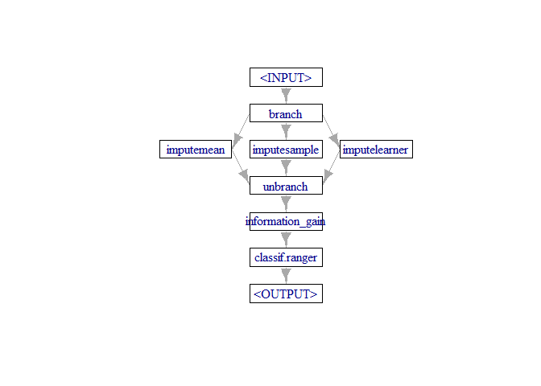

```r
library("mlr3verse")
filter = po("filter", filter = flt("information_gain"))
impute = list(
  "imputemean" = po("imputemean"),
  "imputesample" = po("imputesample"),
  "imputerpart" = po("imputelearner", learner = lrn("regr.rpart"))
)
ranger = lrn("classif.ranger", num.trees = 100)
graph = ppl("branch", impute) %>>% filter %>>% ranger
# Visualize the ML pipeline graph
plot(graph)
```

```r
glrn = as_learner(graph, id = "imputed.filtered.ranger")
```

Note that the `GraphLearner` combines also the hyperparameters of the learner and all other preprocessing methods. You can run the code above as we want use it in order to automatically tune the hyperparameters of the `GraphLearner` and benchmark it with some other learners.

## Create a Search Space

The elements of the above graph have different hyperparameters which can be tuned (see the output of `glrn$param_set` for the names of the hyperparameters). Set up a search space for

- the number of features to filter `information_gain.filter.nfeat` by allowing values between `2L` and `20L`
- the imputation method `branch.selection` by allowing all 3 values: `imputemean`, `imputesample`, `imputerpart`

**Hint 1:**

The names of the hyperparameters could be extracted from `graph$param_set`. Use `ps()` to create a search space. Use `p_int()` to define the search range for integer hyperparameters as required by `information_gain.filter.nfeat` and `p_fct()` for categorical hyperparameters as required by `branch.selection`.

**Hint 2:**

```r
tune_ps = ps(
  ?? = p_int(2L, 20L),
  branch.selection = ??
)
```

### Solution:

**Click me:**

```r
tune_ps = ps(
  information_gain.filter.nfeat = p_int(2L, 20L),
  branch.selection = p_fct(c("imputemean", "imputesample", "imputerpart"))
)
```

## Find the best Hyperparameters

Use the defined search space to automatically tune the number of features for filtering and the imputation method of the `GraphLearner` by setting up an `AutoTuner` object with

- grid search as the tuner, with a resolution of 8, meaning that if possible up to 8 equidistant values are produced per hyperparameter
- the classification error `msr("classif.ce")` as performance measure
- 3-fold CV as resampling strategy

Set a seed for reproducibility (e.g., `set.seed(2023)`).

**Recap `AutoTuner`:**

The `AutoTuner` has the advantage over the tuning via `TuningInstanceSingleCrit` or `TuningInstanceMultiCrit` that we do not need to extract information on the best hyperparameter settings at the end. Instead, the learner is automatically trained on the whole dataset with the best hyperparameter setting after tuning.

The `AutoTuner` wraps a learner and augments it with an automatic tuning process for a given set of hyperparameters. Because the AutoTuner itself inherits from the Learner base class, it can be used like any other learner. The only difference is that `train()` triggers the whole tuning process.

**Hint 1:**

With `auto_tuner()` a new `AutoTuner` instance can be initialized. The initialization method requires the following as an input

- the `GraphLearner` from the previous exercise
- the hyperparameter search space (which we have already set up)
- a resampling instance initialized with `rsmp()` - the 3-fold cross-validation
- a performance measure - the classification error
- a termination criterion, which is `trm("none")` in our case since we specify the number of resolutions in the tuner
- the tuner, i.e., grid search with its `resolution`.

**Hint 2:**

```r
set.seed(2023)
glrn_tuned = auto_tuner(learner = ...,
  search_space = ...,
  resampling = rsmp("...", folds = ...),
  measure = msr("..."),
  terminator = trm("none"),
  tuner = tnr("...", resolution = 8))
glrn_tuned$train(task)
```